# Time Series Analysis Spring 2023

11. GARCH models

Maciej Świtała

11/05/2023

# Loading packages

```r
library(tidyverse)
library(xts) # e.g. xts objects
library(fBasics) # e.g. basicStats()
library(tseries)# e.g. jarque.bera.test()
# library(car) # e.g. durbinWatsonTest()
library(FinTS) # e.g. ArchTest()
library(fGarch) # e.g. garchFit()
library(quantmod) # e.g. getSymbol()
```

If necessary, first install them with the `install.packages()` function.

Lets load additional function defined which will be used to to easily compare information criteria for ARCH and GARCH models.

```r
source("functions/compare_ICs_GARCH.R")
```

# Stylized facts

Lets import the data with prices of SP500 directly from Yahoo! Finance by the `getSymbols()` function from the `quantmod` package. We need to know a correct ticker. For the world indices please refer to: https://finance.yahoo.com/world-indices.

We will work today with `^GSPC`, ie. with the S&P500 index.

```r
SP500 <-
  getSymbols(Symbols = "^GSPC",
             from = "1970-01-01",
             to = "2019-05-07",
             auto.assign = FALSE)
```

Let’s verify the structure:

```r
head(SP500)
```

```
##            GSPC.Open GSPC.High GSPC.Low GSPC.Close GSPC.Volume GSPC.Adjusted
## 1970-01-02         0     93.54    91.79      93.00     8050000         93.00
## 1970-01-05         0     94.25    92.53      93.46    11490000         93.46
## 1970-01-06         0     93.81    92.13      92.82    11460000         92.82
## 1970-01-07         0     93.38    91.93      92.63    10010000         92.63
## 1970-01-08         0     93.47    91.99      92.68    10670000         92.68
## 1970-01-09         0     93.25    91.82      92.40     9380000         92.40
```

```r
tail(SP500)
```

```
##            GSPC.Open GSPC.High GSPC.Low GSPC.Close GSPC.Volume GSPC.Adjusted
## 2019-04-29   2940.58   2949.52  2939.35    2943.03  3150390000       2943.03
## 2019-04-30   2937.14   2948.22  2924.11    2945.83  3939760000       2945.83
## 2019-05-01   2952.33   2954.13  2923.36    2923.73  3669330000       2923.73
## 2019-05-02   2922.16   2931.68  2900.50    2917.52  3802290000       2917.52
## 2019-05-03   2929.21   2947.85  2929.21    2945.64  3357180000       2945.64
## 2019-05-06   2908.89   2937.32  2898.21    2932.47  3203260000       2932.47
```

```r
str(SP500)
```

```
## An xts object on 1970-01-02 / 2019-05-06 containing:
##   Data:    double [12447, 6]
##   Columns: GSPC.Open, GSPC.High, GSPC.Low, GSPC.Close, GSPC.Volume ... with 1 more column
##   Index:   Date [12447] (TZ: "UTC")
##   xts Attributes:
##     $ src    : chr "yahoo"
##     $ updated: POSIXct[1:1], format: "2023-05-10 15:25:04"
```

We will include only the adjustted close price (Adjusted) and change its name to SP500.

```r
SP500 <- SP500[, 6]
names(SP500) <- "SP500"
```

Also, we will add log-returns to the data

```r
SP500$r <- diff.xts(log(SP500$SP500))
```

Finally, we limit our data to days since the beginning of 2000:

```r
SP500 <- SP500["2000/",]
```

Now, let’s plot the close price

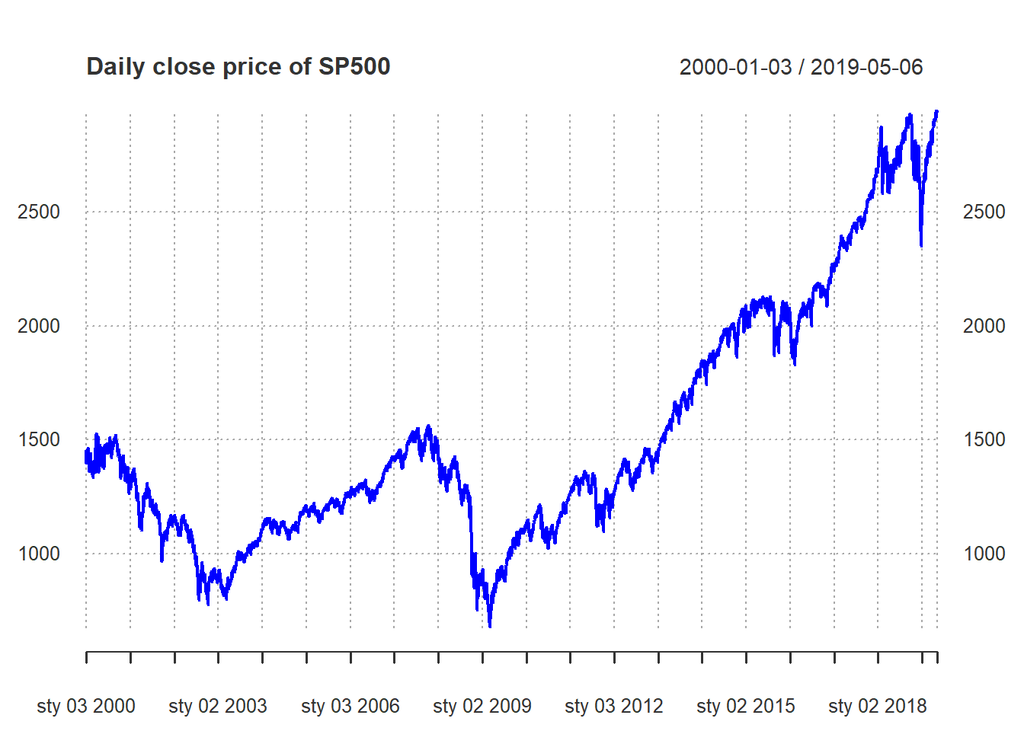

```r
plot(SP500$SP500,
     col = "blue",
     major.ticks = "years",
     grid.ticks.on = "years",
     grid.ticks.lty = 3,
     main = "Daily close price of SP500")
```

… and it’s log-returns:

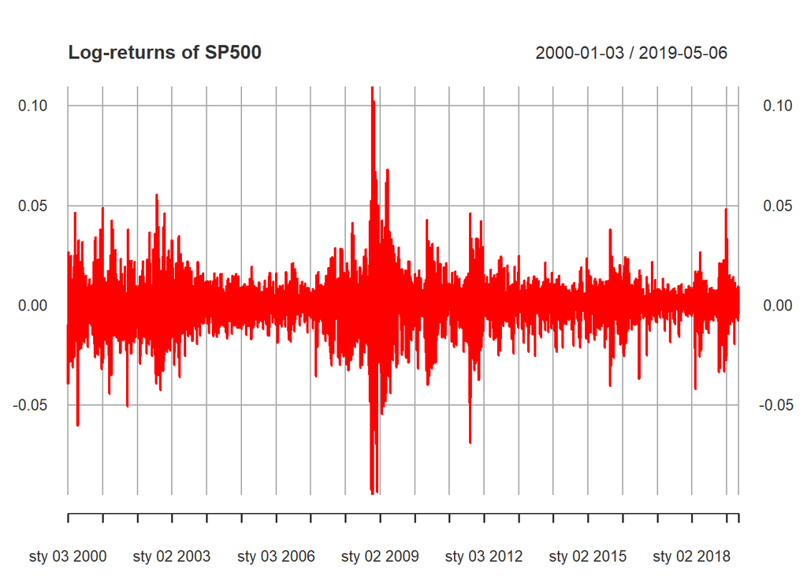

```r
plot(SP500$r,
     col = "red",
     major.ticks = "years",
     grid.ticks.on = "years",
     main = "Log-returns of SP500")
```

Let’s also plot the ACF function of log-returns:

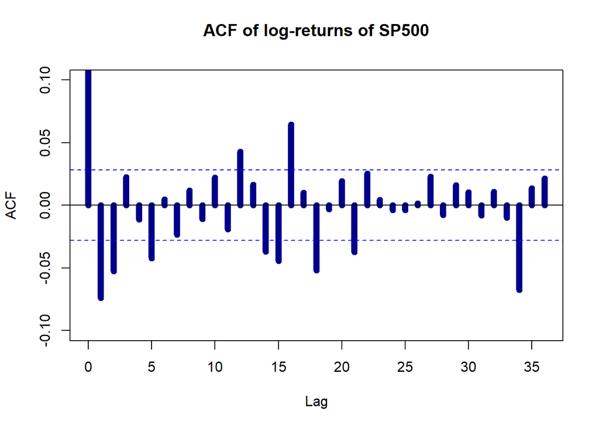

```r
acf(SP500$r,
    lag.max = 36,
    na.action = na.pass,
    ylim = c(-0.1,0.1), # we rescale the vertical axis
    col = "darkblue",
    lwd = 7,
    main = "ACF of log-returns of SP500")
```

As we see, values of the ACF function indicate some autoregressive/MA relations among returns which can be used to build an ARIMA model.

Now, let’s also see the ACF values for for the **squared** log-returns:

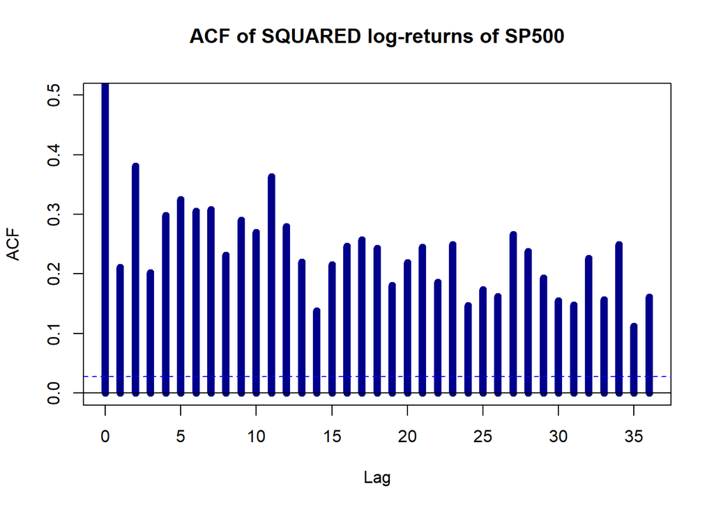

```r
acf(SP500$r ^ 2,
    lag.max = 36,
    na.action = na.pass,
    ylim = c(0,0.5), # we rescale the vertical axis
    col = "darkblue",
    lwd = 7,
    main = "ACF of SQUARED log-returns of SP500")
```

This in turn indicates some autoregressive relations among **squared** returns (actually their ralized variance!) which can be used to build a (G)ARCH model.

Do log-returns follow a normal distribution?

```r
basicStats(SP500$r)
```

```
##                       r
## nobs        4865.000000
## NAs            0.000000
## Minimum       -0.094695
## Maximum        0.109572
## 1. Quartile   -0.004799
## 3. Quartile    0.005645
## Mean           0.000142
## Median         0.000533
## Sum            0.691093
## SE Mean        0.000172
## LCL Mean      -0.000195
## UCL Mean       0.000480
## Variance       0.000144
## Stdev          0.012008
## Skewness      -0.218667
## Kurtosis       8.560653
```

Skewness is negative and we also observe strong excess kurtosis.

Let’s see whether it is also confirmed by the histogram:

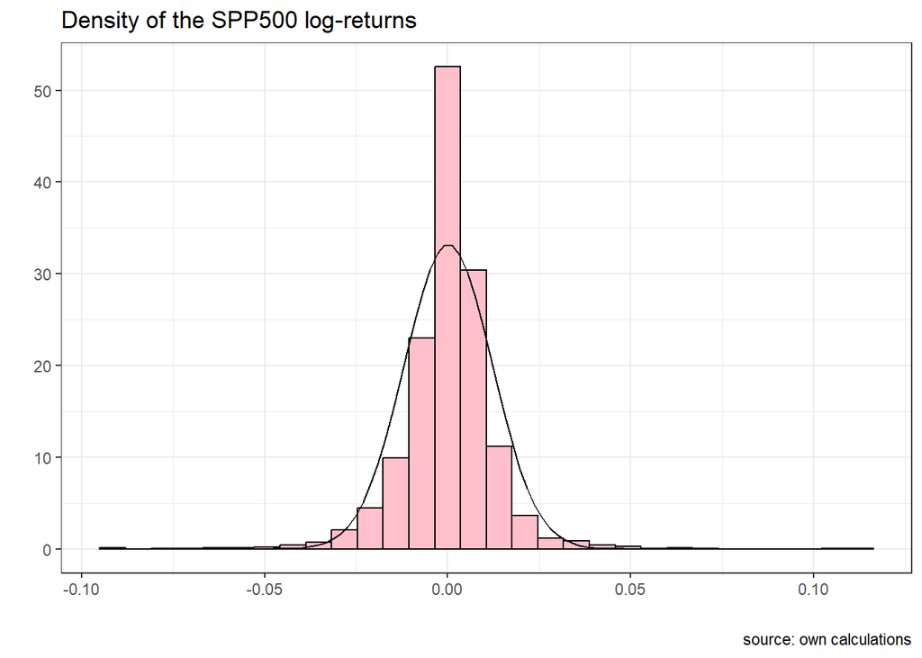

```r
tibble(r = as.numeric(SP500$r)) %>%
  ggplot(aes(r)) +
  geom_histogram(aes(y =..density..),
                 colour = "black",
                 fill = "pink") +
  stat_function(fun = dnorm,
                args = list(mean = mean(SP500$r),
                            sd = sd(SP500$r))) +
  theme_bw() +
  labs(
    title = "Density of the SPP500 log-returns",
    y = "", x = "",
    caption = "source: own calculations"
  )
```

As we can see, the distribution of the returns is **highly leptokurtic**.

Let’s also examine the Jarque-Bera statistic:

```r
jarque.bera.test(SP500$r)
```

```
##
##  Jarque Bera Test
##
## data:  SP500$r
## X-squared = 14911, df = 2, p-value < 2.2e-16
```

The null hypothesis about normality strongly rejected!

Finally, let’s verify existence of ARCH effects among log-returns. The ARCH test is based on the autocorrelation of **squared** returns.

```r
ArchTest(SP500$r,  # here we use a vector of returns as input
         lags = 5) # and maximum order of ARCH effect
```

```
##
##  ARCH LM-test; Null hypothesis: no ARCH effects
##
## data:  SP500$r
## Chi-squared = 1120, df = 5, p-value < 2.2e-16
```

The null hypothesis about lack of ARCH effects strongly rejected!

# Modelling

Now, we will find the most attractive GARCH(q, p) model.

## ARCH vs. GARCH models

### ARCH(1)

```r
k.arch1 <- garchFit(formula = ~ garch(1, 0), # GARCH(q, p)
                    # formula describing the mean and variance equation
                    # of the ARMA-GARCH - we assume that returns
                    # follow an ARCH(1) process
                    data = SP500$r,
                    # conditional distribution of errors
                    cond.dist = "norm",
                    # if we don't want to see the history of iterations
                    trace = FALSE)
```

Summary of results and some diagnostic tests:

```r
summary(k.arch1)
```

```
##
## Title:
##  GARCH Modelling
##
## Call:
##  garchFit(formula = ~garch(1, 0), data = SP500$r, cond.dist = "norm",
##     trace = FALSE)
##
## Mean and Variance Equation:
##  data ~ garch(1, 0)
## <environment: 0x0000025353ee7e78>
##  [data = SP500$r]
##
## Conditional Distribution:
##  norm
##
## Coefficient(s):
##          mu        omega       alpha1
## 0.000351814  0.000098073  0.355729089
##
## Std. Errors:
##  based on Hessian
##
## Error Analysis:
##           Estimate  Std. Error  t value Pr(>|t|)
## mu     0.000351814 0.000148375    2.371   0.0177 *
## omega  0.000098073 0.000002723   36.020   <2e-16 ***
## alpha1 0.355729089 0.030108888   11.815   <2e-16 ***
## ---
## Signif. codes:  0 '***' 0.001 '**' 0.01 '*' 0.05 '.' 0.1 ' ' 1
##
## Log Likelihood:
##  14886.03    normalized:  3.05982
##
## Description:
##  Wed May 10 15:25:06 2023 by user: macie
##
##
## Standardised Residuals Tests:
##                                 Statistic p-Value
##  Jarque-Bera Test   R    Chi^2  13634.64  0
##  Shapiro-Wilk Test  R    W      0.927298  0
##  Ljung-Box Test     R    Q(10)  20.3619   0.0260097
##  Ljung-Box Test     R    Q(15)  44.38323  0.00009575553
##  Ljung-Box Test     R    Q(20)  65.77269  0.0000008784978
##  Ljung-Box Test     R^2  Q(10)  1418.588  0
##  Ljung-Box Test     R^2  Q(15)  1842.784  0
##  Ljung-Box Test     R^2  Q(20)  2113.468  0
##  LM Arch Test       R    TR^2   897.8049  0
##
## Information Criterion Statistics:
##       AIC       BIC       SIC      HQIC
## -6.118407 -6.114405 -6.118408 -6.117003
```

The parameters are denoted by the following symbols:

- mu - constant term in the mean equation
- omega - constant term in the variance equation
- alpha1 - arch1 parameter in the variance equation

```r
k.arch1a <- garchFit(~garch(1, 0),
                     data = SP500$r,
                     # remove intercept term in the mean equation
                     include.mean = FALSE,
                     # conditional distribution of errors
                     cond.dist = "norm",
                     trace = FALSE)
```

Again, summary of results and some diagnostic tests:

```r
summary(k.arch1a)
```

```
##
## Title:
##  GARCH Modelling
##
## Call:
##  garchFit(formula = ~garch(1, 0), data = SP500$r, cond.dist = "norm",
##     include.mean = FALSE, trace = FALSE)
##
## Mean and Variance Equation:
##  data ~ garch(1, 0)
## <environment: 0x00000253509059d0>
##  [data = SP500$r]
##
## Conditional Distribution:
##  norm
##
## Coefficient(s):
##       omega       alpha1
## 0.000098397  0.352003306
##
## Std. Errors:
##  based on Hessian
##
## Error Analysis:
##           Estimate  Std. Error  t value Pr(>|t|)
## omega  0.000098397 0.000002728    36.07   <2e-16 ***
## alpha1 0.352003306 0.029872896    11.78   <2e-16 ***
## ---
## Signif. codes:  0 '***' 0.001 '**' 0.01 '*' 0.05 '.' 0.1 ' ' 1
##
## Log Likelihood:
##  14883.22    normalized:  3.059244
##
## Description:
##  Wed May 10 15:25:06 2023 by user: macie
##
##
## Standardised Residuals Tests:
##                                 Statistic p-Value
##  Jarque-Bera Test   R    Chi^2  13692.77  0
##  Shapiro-Wilk Test  R    W      0.9271653 0
##  Ljung-Box Test     R    Q(10)  19.85235  0.03068054
##  Ljung-Box Test     R    Q(15)  44.08968  0.0001064649
##  Ljung-Box Test     R    Q(20)  65.68863  0.0000009061183
##  Ljung-Box Test     R^2  Q(10)  1446.265  0
##  Ljung-Box Test     R^2  Q(15)  1875.078  0
##  Ljung-Box Test     R^2  Q(20)  2147.997  0
##  LM Arch Test       R    TR^2   912.6403  0
##
## Information Criterion Statistics:
##       AIC       BIC       SIC      HQIC
## -6.117666 -6.114998 -6.117666 -6.116729
```

Now, let’s examine squares of standardized residuals. To do this we can use the `plot()` function which helps plot automatically several parts of the results. Calling the `plot()` function with the object of class `fGARCH` will enter the interactive mode which offers a selection of 13 plots:

```
Make a plot selection (or 0 to exit):

 1:   Time Series
 2:   Conditional SD
 3:   Series with 2 Conditional SD Superimposed
 4:   ACF of Observations
 5:   ACF of Squared Observations
 6:   Cross Correlation
 7:   Residuals
 8:   Conditional SDs
 9:   Standardized Residuals
10:   ACF of Standardized Residuals
11:   ACF of Squared Standardized Residuals
12:   Cross Correlation between r^2 and r
13:   QQ-Plot of Standardized Residuals
```

First, let’s see all of them:

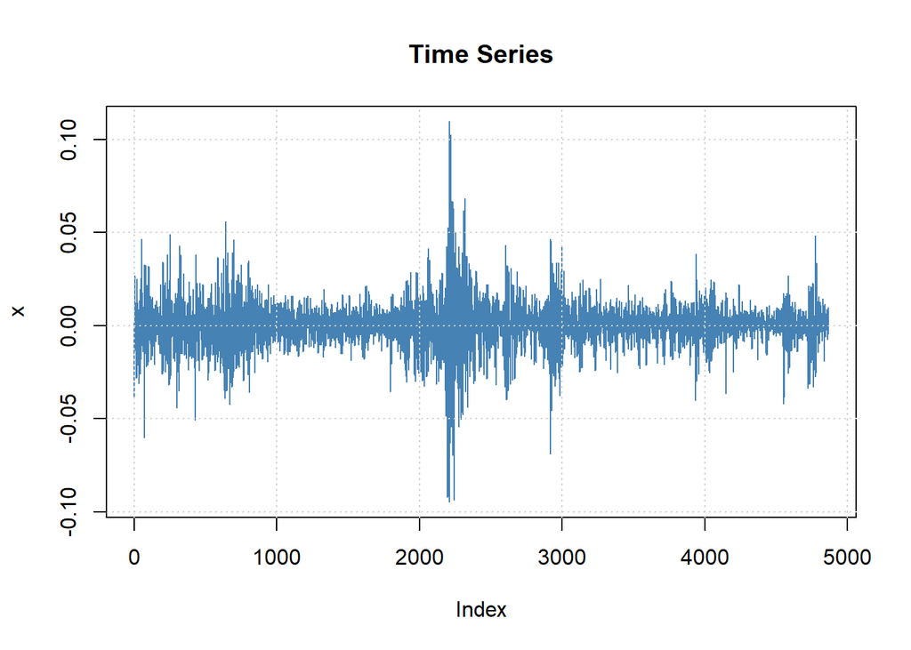

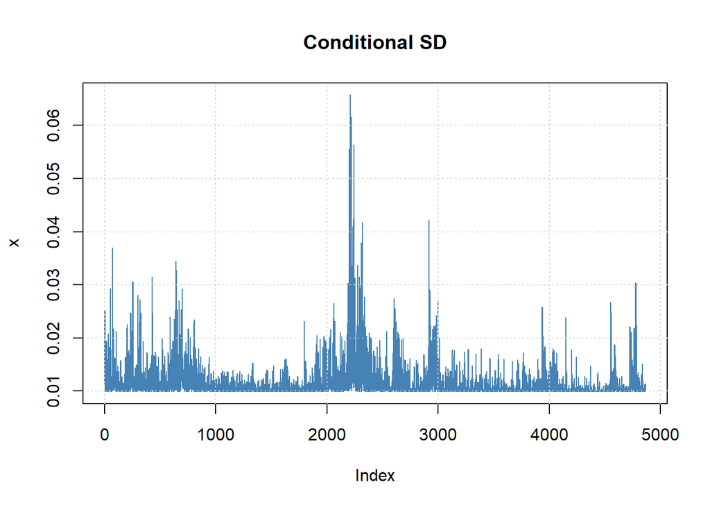

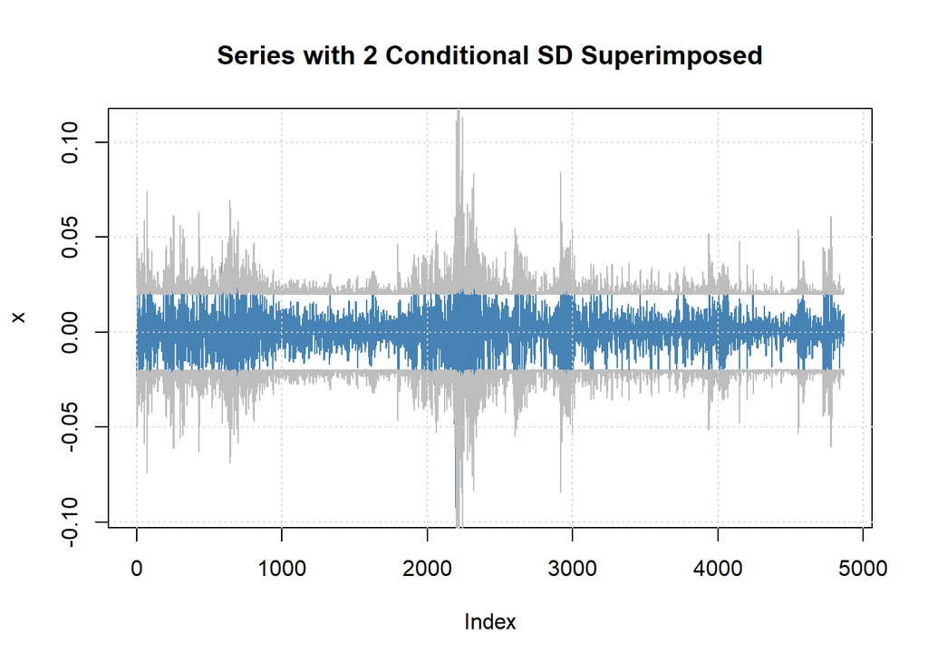

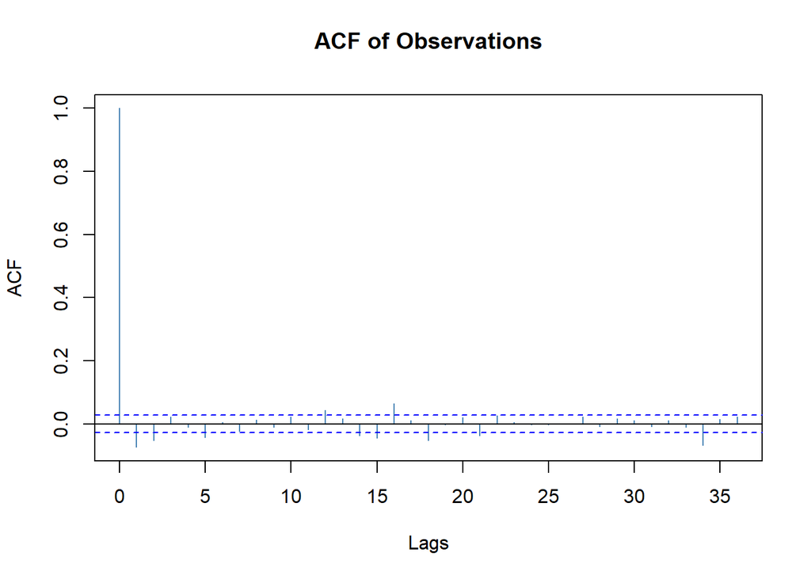

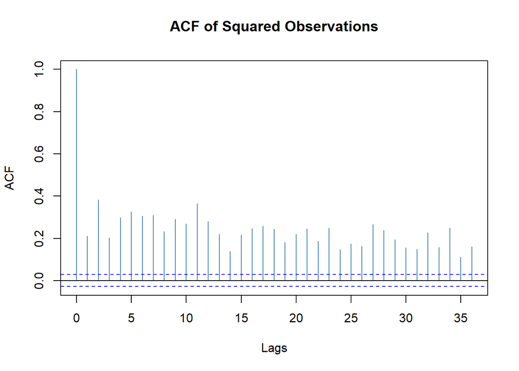

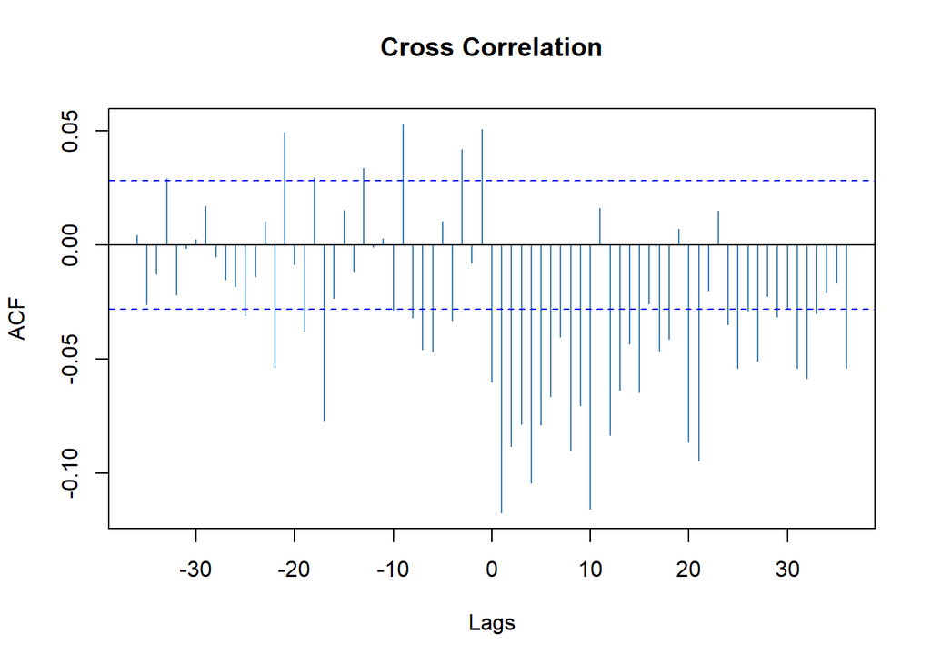

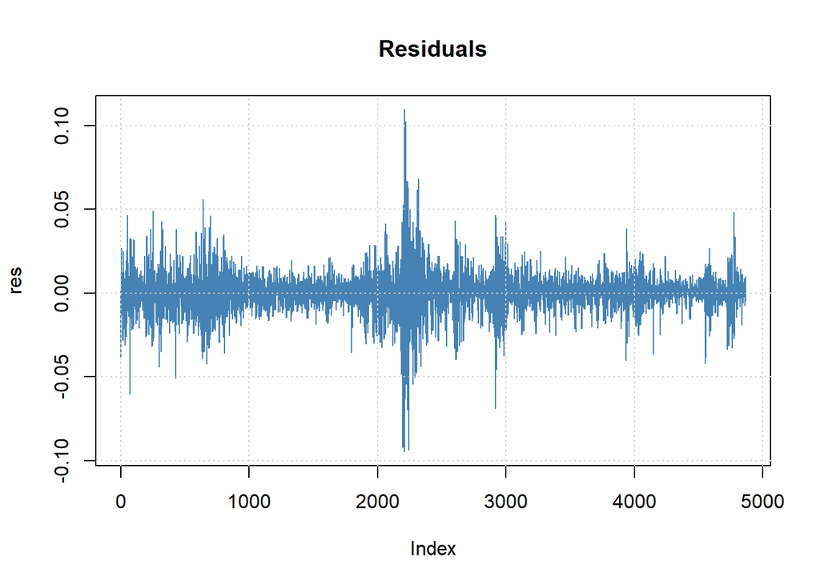

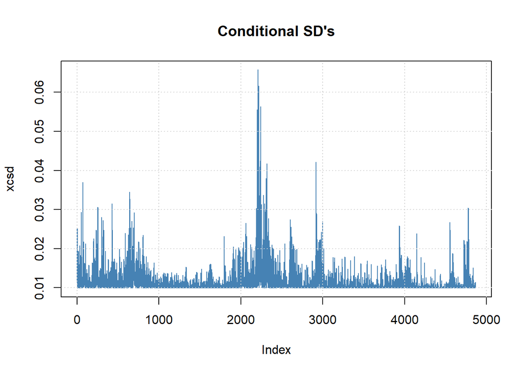

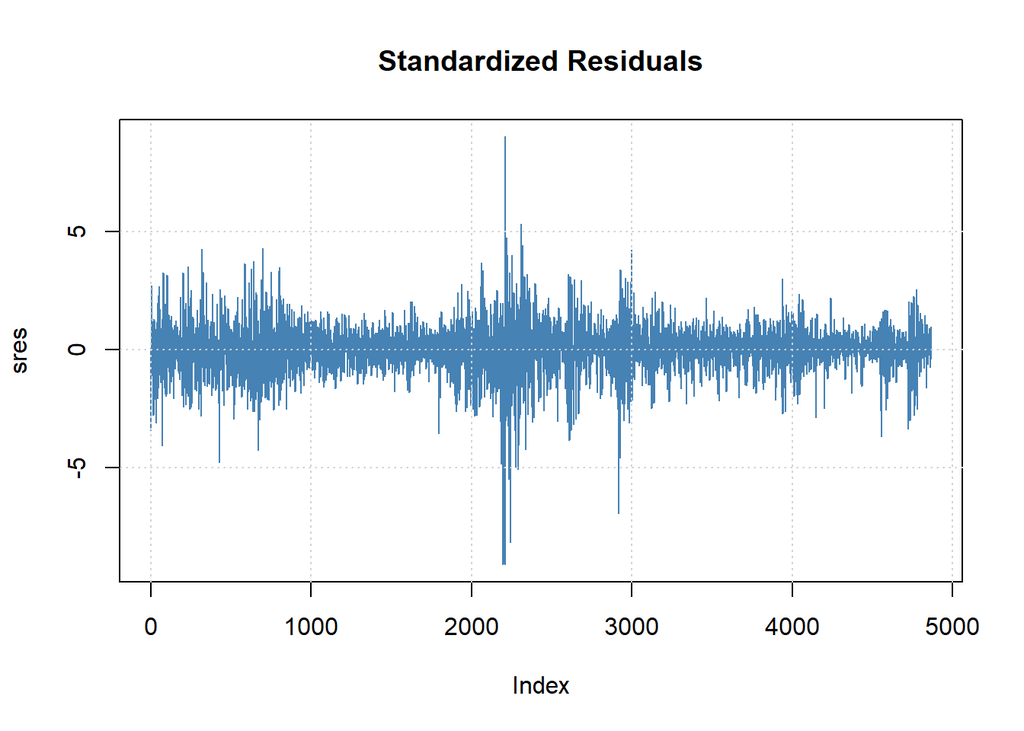

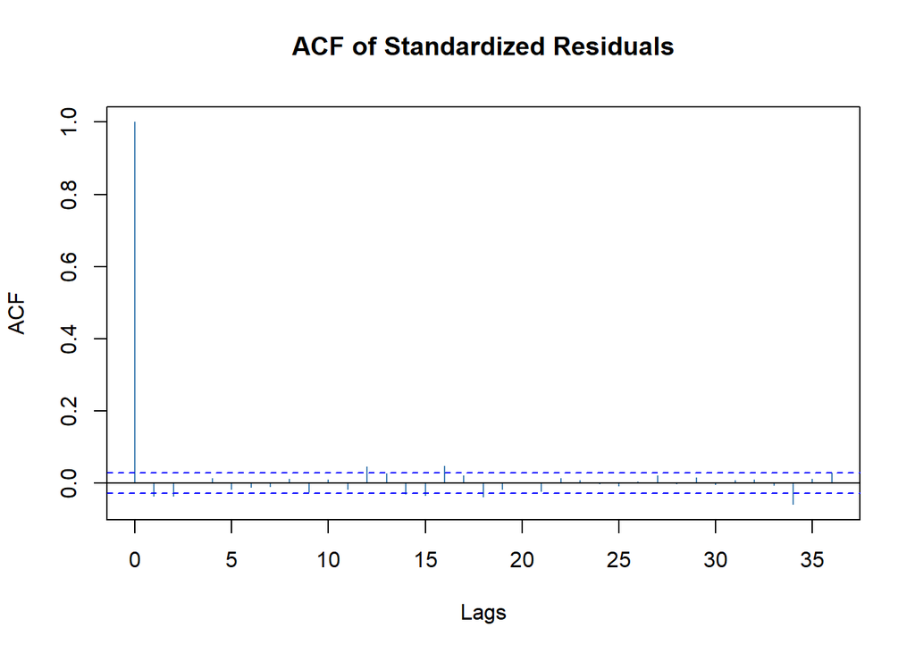

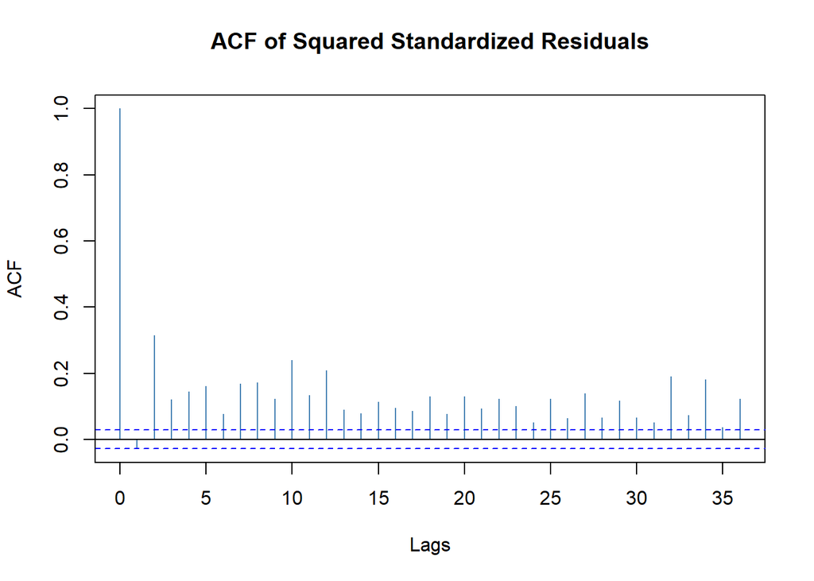

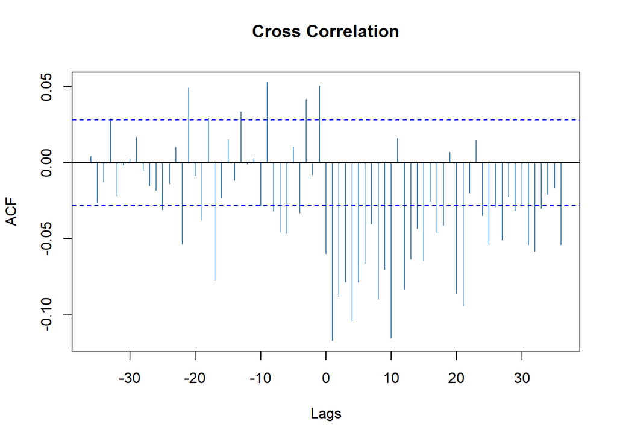

[1 more figures not shown]

```r
for (i in 1:13) plot(k.arch1a, which = i)
```

If you call `plot(k.arch1a)` in the console - remember to quit by pressing ESC before you continue!

For now, most interesting for us are:

```
10: ACF of Standardized Residuals,
11: ACF of Squared Standardized Residuals;
2: Conditional SD
```

Hence, let’s call the `plot()` function again:

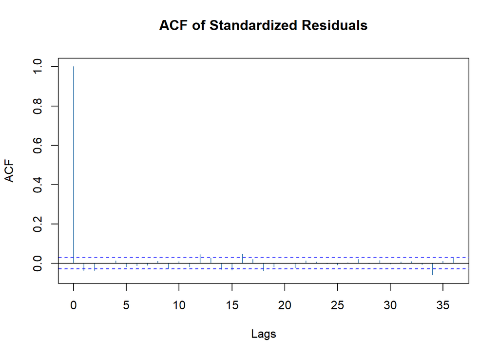

```r
plot(k.arch1a, which = 10)
```

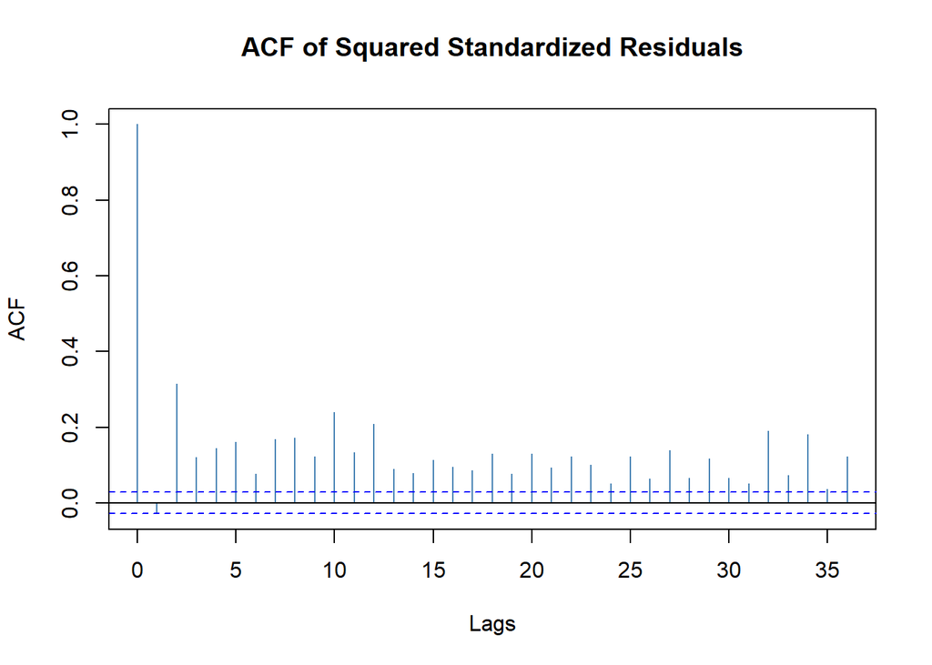

```r
plot(k.arch1a, which = 11)
```

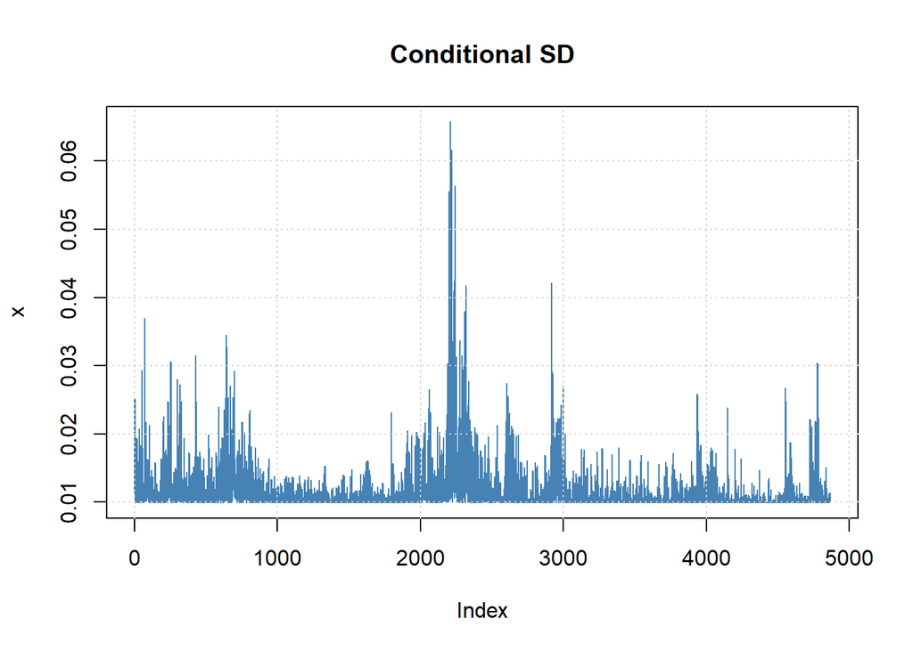

```r
plot(k.arch1a, which = 2)
```

The conclusion is that squared residuals still have significant ACF for lags 2-10.

### ARCH(5)

Lets try if ARCH(5) is enough to catch this phenomenon:

```r
k.arch5 <- garchFit(~garch(5, 0),
                    data = SP500$r,
                    include.mean = TRUE,
                    cond.dist = "norm",
                    trace = FALSE)
summary(k.arch5)
```

```
##
## Title:
##  GARCH Modelling
##
## Call:
##  garchFit(formula = ~garch(5, 0), data = SP500$r, cond.dist = "norm",
##     include.mean = TRUE, trace = FALSE)
##
## Mean and Variance Equation:
##  data ~ garch(5, 0)
## <environment: 0x000002534fb5fc98>
##  [data = SP500$r]
##
## Conditional Distribution:
##  norm
##
## Coefficient(s):
##          mu        omega       alpha1       alpha2       alpha3       alpha4
## 0.000577157  0.000027598  0.104965100  0.201833012  0.187364106  0.195080615
##      alpha5
## 0.153511847
##
## Std. Errors:
##  based on Hessian
##
## Error Analysis:
##           Estimate  Std. Error  t value        Pr(>|t|)
## mu     0.000577157 0.000111389    5.181 0.0000002201694 ***
## omega  0.000027598 0.000001606   17.185         < 2e-16 ***
## alpha1 0.104965100 0.015549121    6.751 0.0000000000147 ***
## alpha2 0.201833012 0.020815732    9.696         < 2e-16 ***
## alpha3 0.187364106 0.019997262    9.369         < 2e-16 ***
## alpha4 0.195080615 0.020787527    9.385         < 2e-16 ***
## alpha5 0.153511847 0.018332430    8.374         < 2e-16 ***
## ---
## Signif. codes:  0 '***' 0.001 '**' 0.01 '*' 0.05 '.' 0.1 ' ' 1
##
## Log Likelihood:
##  15654.81    normalized:  3.217844
##
## Description:
##  Wed May 10 15:25:09 2023 by user: macie
##
##
## Standardised Residuals Tests:
##                                 Statistic p-Value
##  Jarque-Bera Test   R    Chi^2  708.5792  0
##  Shapiro-Wilk Test  R    W      0.9806016 0
##  Ljung-Box Test     R    Q(10)  18.14099  0.05263144
##  Ljung-Box Test     R    Q(15)  28.62981  0.01794314
##  Ljung-Box Test     R    Q(20)  37.78029  0.009419002
##  Ljung-Box Test     R^2  Q(10)  57.39764  0.00000001122242
##  Ljung-Box Test     R^2  Q(15)  65.84961  0.00000002423942
##  Ljung-Box Test     R^2  Q(20)  79.23939  0.00000000528311
##  LM Arch Test       R    TR^2   66.91782  0.000000001202746
##
## Information Criterion Statistics:
##       AIC       BIC       SIC      HQIC
## -6.432811 -6.423473 -6.432815 -6.429533
```

All parameters are significant. The Ljung-box tests for R and R^2 show there is still autocorrelation.

Let’s plot the ACF of standardized residuals and standardized squared residuals (plots 10 and 11).

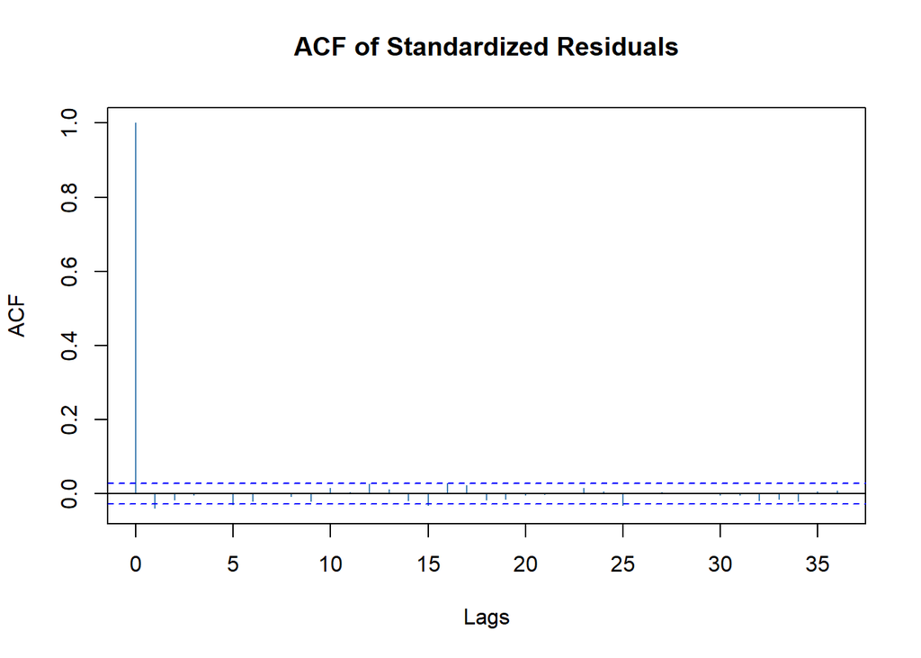

```r
plot(k.arch5, which = 10)
```

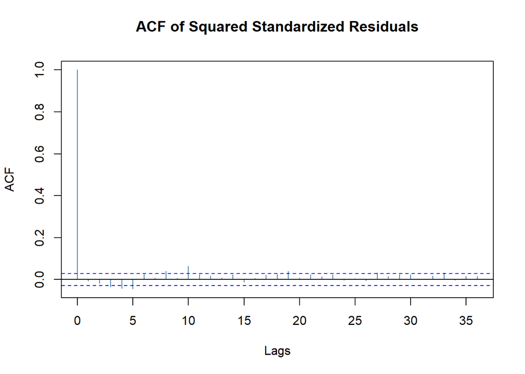

```r
plot(k.arch5, which = 11)
```

The lags 3-5, 8, 10 in ACF for squared residuals seem to be still significant.

### ARCH(10)

Let’s now estimate the ARCH(10) model:

```r
k.arch10 <- garchFit(~garch(10, 0),
                     data = SP500$r,
                     include.mean = TRUE,
                     cond.dist = "norm",
                     trace = FALSE)
summary(k.arch10)
```

```
##
## Title:
##  GARCH Modelling
##
## Call:
##  garchFit(formula = ~garch(10, 0), data = SP500$r, cond.dist = "norm",
##     include.mean = TRUE, trace = FALSE)
##
## Mean and Variance Equation:
##  data ~ garch(10, 0)
## <environment: 0x00000253503b0600>
##  [data = SP500$r]
##
## Conditional Distribution:
##  norm
##
## Coefficient(s):
##          mu        omega       alpha1       alpha2       alpha3       alpha4
## 0.000563421  0.000018783  0.068117427  0.140397572  0.104922457  0.115347291
##      alpha5       alpha6       alpha7       alpha8       alpha9      alpha10
## 0.078852795  0.067397720  0.063428123  0.099494839  0.070354354  0.071306154
##
## Std. Errors:
##  based on Hessian
##
## Error Analysis:
##            Estimate  Std. Error  t value          Pr(>|t|)
## mu      0.000563421 0.000111132    5.070 0.000000398185556 ***
## omega   0.000018783 0.000001486   12.638           < 2e-16 ***
## alpha1  0.068117427 0.014323202    4.756 0.000001977206631 ***
## alpha2  0.140397572 0.018921154    7.420 0.000000000000117 ***
## alpha3  0.104922457 0.017679978    5.935 0.000000002946785 ***
## alpha4  0.115347291 0.019419016    5.940 0.000000002851710 ***
## alpha5  0.078852795 0.016074215    4.906 0.000000931679546 ***
## alpha6  0.067397720 0.016597108    4.061 0.000048902548723 ***
## alpha7  0.063428123 0.015326817    4.138 0.000034977385341 ***
## alpha8  0.099494839 0.018351680    5.422 0.000000059079257 ***
## alpha9  0.070354354 0.017278052    4.072 0.000046632876609 ***
## alpha10 0.071306154 0.016712087    4.267 0.000019834870046 ***
## ---
```

[output cut: 9 more lines]

```
## Standardised Residuals Tests:
##                                 Statistic p-Value
##  Jarque-Bera Test   R    Chi^2  658.91    0
##  Shapiro-Wilk Test  R    W      0.9832948 0
##  Ljung-Box Test     R    Q(10)  22.21621  0.01404024
##  Ljung-Box Test     R    Q(15)  34.83663  0.002594172
##  Ljung-Box Test     R    Q(20)  43.4096   0.001804148
##  Ljung-Box Test     R^2  Q(10)  8.423611  0.5875324
##  Ljung-Box Test     R^2  Q(15)  11.59125  0.7096671
##  Ljung-Box Test     R^2  Q(20)  13.80313  0.840336
##  LM Arch Test       R    TR^2   8.817151  0.7184638
##
## Information Criterion Statistics:
##       AIC       BIC       SIC      HQIC
## -6.476821 -6.460813 -6.476833 -6.471203
```

Again all parameters are significant at 5% level. The Ljung-box test for R^2 shows there is no more autocorrelation between the current and past standardized **squared** residuals.

Lets plot the ACF of standardized residuals and standardized squared residuals (plots 10 and 11).

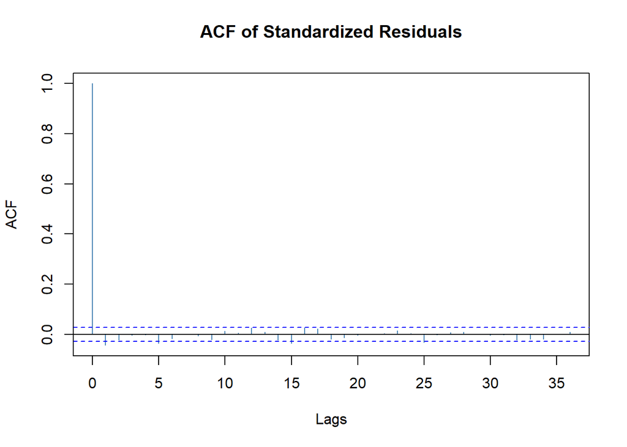

```r
plot(k.arch10, which = 10)
```

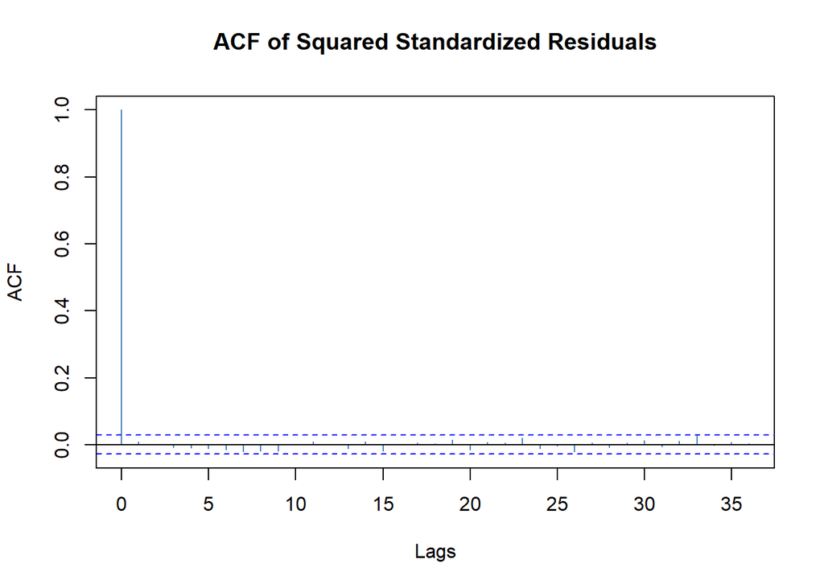

```r
plot(k.arch10, which = 11)
```

It looks like no further extension of the **conditional variance** equation is needed. However, we can consider adding some AR part in the **mean** equation (we will do it later).

### GARCH(1,1)

Let’s now compare the last model with GARCH(1,1).

```r
k.garch11 <- garchFit(~garch(1, 1),
                      data = SP500$r,
                      include.mean = TRUE,
                      cond.dist = "norm",
                      trace = FALSE)
summary(k.garch11)
```

```
##
## Title:
##  GARCH Modelling
##
## Call:
##  garchFit(formula = ~garch(1, 1), data = SP500$r, cond.dist = "norm",
##     include.mean = TRUE, trace = FALSE)
##
## Mean and Variance Equation:
##  data ~ garch(1, 1)
## <environment: 0x00000253541c1538>
##  [data = SP500$r]
##
## Conditional Distribution:
##  norm
##
## Coefficient(s):
##           mu         omega        alpha1         beta1
## 0.0005558010  0.0000019249  0.1088309952  0.8761242154
##
## Std. Errors:
##  based on Hessian
##
## Error Analysis:
##            Estimate   Std. Error  t value         Pr(>|t|)
## mu     0.0005558010 0.0001128645    4.924 0.00000084576567 ***
## omega  0.0000019249 0.0000002773    6.942 0.00000000000388 ***
## alpha1 0.1088309952 0.0093371631   11.656          < 2e-16 ***
## beta1  0.8761242154 0.0097803345   89.580          < 2e-16 ***
## ---
## Signif. codes:  0 '***' 0.001 '**' 0.01 '*' 0.05 '.' 0.1 ' ' 1
##
## Log Likelihood:
##  15767.93    normalized:  3.241095
##
## Description:
##  Wed May 10 15:25:44 2023 by user: macie
##
##
## Standardised Residuals Tests:
##                                 Statistic p-Value
##  Jarque-Bera Test   R    Chi^2  775.3048  0
##  Shapiro-Wilk Test  R    W      0.9825704 0
##  Ljung-Box Test     R    Q(10)  22.86762  0.01124592
##  Ljung-Box Test     R    Q(15)  33.83814  0.003588078
##  Ljung-Box Test     R    Q(20)  42.1481   0.002645244
##  Ljung-Box Test     R^2  Q(10)  15.80684  0.1052969
##  Ljung-Box Test     R^2  Q(15)  22.2003   0.1026583
##  Ljung-Box Test     R^2  Q(20)  24.19599  0.2339357
##  LM Arch Test       R    TR^2   16.24279  0.1803674
##
## Information Criterion Statistics:
##       AIC       BIC       SIC      HQIC
## -6.480545 -6.475209 -6.480547 -6.478673
```

All parameters are significant. The Ljung-Box test for R^2 does not show autocorrelation at 5% level between the current and past standardized squared residuals (variance).

Let’s plot the ACF of standardized residuals and standardized squared residuals (plots 10 and 11).

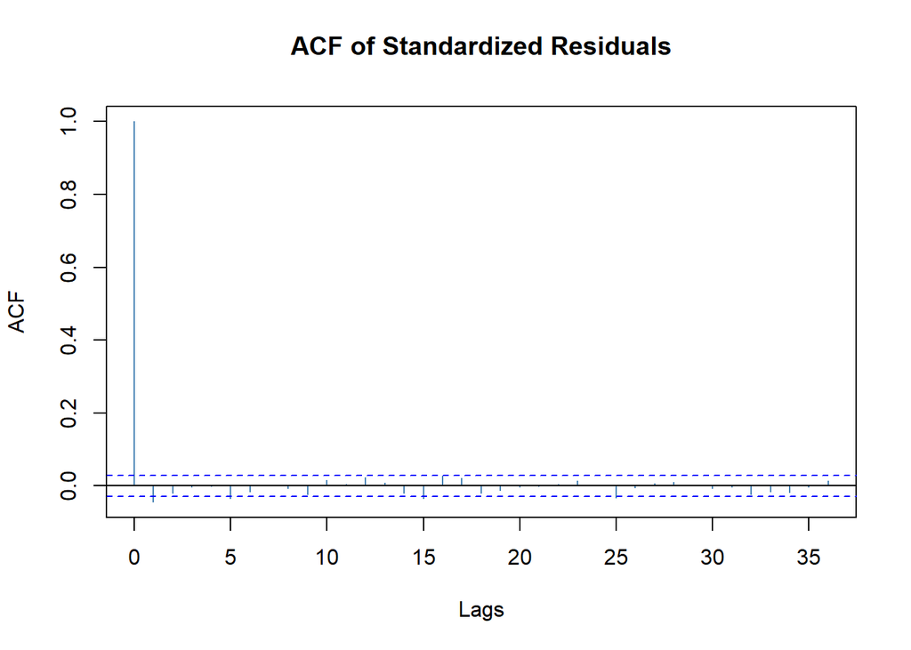

```r
plot(k.garch11, which = 10)
```

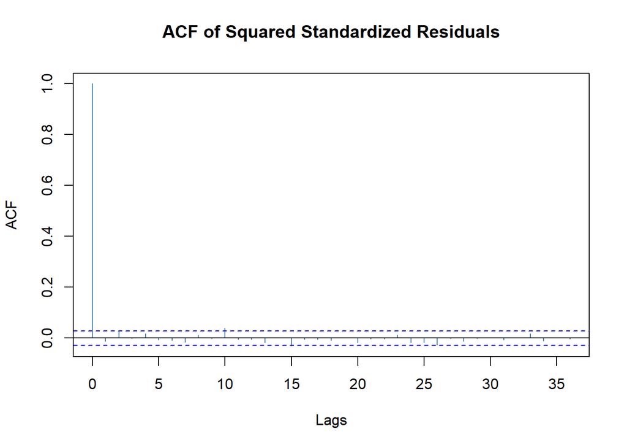

```r
plot(k.garch11, which = 11)
```

ACF for R^2 of order 2 seems to be on the border of significance.

Hence, let’s check the higher order model of GARCH(2,1).

### GARCH(2,1)

```r
k.garch21 <- garchFit(~ garch(2, 1),
                      data = SP500$r,
                      include.mean = TRUE,
                      cond.dist = "norm",
                      trace = FALSE)
summary(k.garch21)
```

```
##
## Title:
##  GARCH Modelling
##
## Call:
##  garchFit(formula = ~garch(2, 1), data = SP500$r, cond.dist = "norm",
##     include.mean = TRUE, trace = FALSE)
##
## Mean and Variance Equation:
##  data ~ garch(2, 1)
## <environment: 0x0000025352289a40>
##  [data = SP500$r]
##
## Conditional Distribution:
##  norm
##
## Coefficient(s):
##           mu         omega        alpha1        alpha2         beta1
## 0.0005614964  0.0000024095  0.0717496956  0.0567031586  0.8528986231
##
## Std. Errors:
##  based on Hessian
##
## Error Analysis:
##            Estimate   Std. Error  t value        Pr(>|t|)
## mu     0.0005614964 0.0001126140    4.986 0.0000006163438 ***
## omega  0.0000024095 0.0000003692    6.525 0.0000000000678 ***
## alpha1 0.0717496956 0.0140003571    5.125 0.0000002977786 ***
## alpha2 0.0567031586 0.0184495220    3.073         0.00212 **
## beta1  0.8528986231 0.0136313040   62.569         < 2e-16 ***
## ---
## Signif. codes:  0 '***' 0.001 '**' 0.01 '*' 0.05 '.' 0.1 ' ' 1
##
## Log Likelihood:
##  15772.56    normalized:  3.242046
##
## Description:
##  Wed May 10 15:25:45 2023 by user: macie
##
##
## Standardised Residuals Tests:
##                                 Statistic p-Value
##  Jarque-Bera Test   R    Chi^2  793.3126  0
##  Shapiro-Wilk Test  R    W      0.9822478 0
##  Ljung-Box Test     R    Q(10)  22.56762  0.01246015
##  Ljung-Box Test     R    Q(15)  33.81627  0.003613471
##  Ljung-Box Test     R    Q(20)  42.15904  0.002636557
##  Ljung-Box Test     R^2  Q(10)  11.7229   0.3040297
##  Ljung-Box Test     R^2  Q(15)  18.03667  0.2607424
##  Ljung-Box Test     R^2  Q(20)  20.12275  0.4502751
##  LM Arch Test       R    TR^2   12.32191  0.4201849
##
## Information Criterion Statistics:
##       AIC       BIC       SIC      HQIC
## -6.482037 -6.475368 -6.482040 -6.479697
```

All parameters are significant. The Ljung-box test for R^2 shows there is no autocorrelation between the current and past standardized squared residuals.

Again, let’s plot the ACF of standardized residuals and standardized squared residuals (plots 10 and 11).

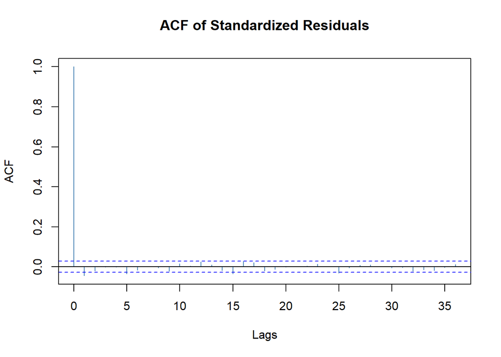

```r
plot(k.garch21, which = 10)
```

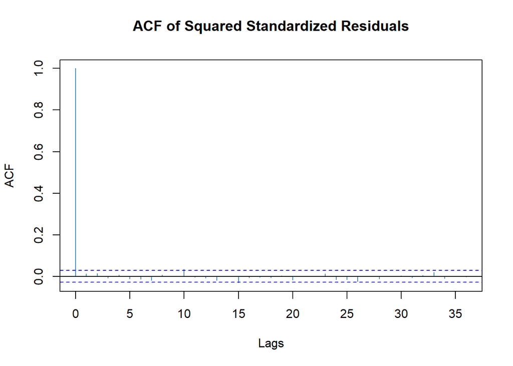

```r
plot(k.garch21, which = 11)
```

The **conditional variance** equation seems to be complete, however the ACF plot of residuals indicates that we may still improve the model by adding AR components in the **mean** equation.

### AR(5)-GARCH(2,1)

Let’s add the AR(5) model into the mean equation:

```r
k.ar5garch21 <- garchFit(~arma(5, 0) + garch(2, 1),
                         data = SP500$r,
                         include.mean = TRUE,
                         cond.dist = "norm",
                         trace = FALSE)
summary(k.ar5garch21)
```

```
##
## Title:
##  GARCH Modelling
##
## Call:
##  garchFit(formula = ~arma(5, 0) + garch(2, 1), data = SP500$r,
##     cond.dist = "norm", include.mean = TRUE, trace = FALSE)
##
## Mean and Variance Equation:
##  data ~ arma(5, 0) + garch(2, 1)
## <environment: 0x0000025353ad2a70>
##  [data = SP500$r]
##
## Conditional Distribution:
##  norm
##
## Coefficient(s):
##            mu            ar1            ar2            ar3            ar4
##  0.0006510745  -0.0619571972  -0.0310592741  -0.0110380532  -0.0103344248
##           ar5          omega         alpha1         alpha2          beta1
## -0.0378877176   0.0000024104   0.0697032348   0.0596562962   0.8521811082
##
## Std. Errors:
##  based on Hessian
##
## Error Analysis:
##             Estimate    Std. Error  t value        Pr(>|t|)
## mu      0.0006510745  0.0001156991    5.627 0.0000000183046 ***
## ar1    -0.0619571972  0.0149170521   -4.153 0.0000327502940 ***
## ar2    -0.0310592741  0.0155031466   -2.003         0.04513 *
## ar3    -0.0110380532  0.0152538456   -0.724         0.46930
## ar4    -0.0103344248  0.0151272876   -0.683         0.49450
## ar5    -0.0378877176  0.0149860308   -2.528         0.01146 *
## omega   0.0000024104  0.0000003691    6.530 0.0000000000656 ***
## alpha1  0.0697032348  0.0137874076    5.056 0.0000004291022 ***
## alpha2  0.0596562962  0.0181845049    3.281         0.00104 **
## beta1   0.8521811082  0.0135677522   62.809         < 2e-16 ***
## ---
## Signif. codes:  0 '***' 0.001 '**' 0.01 '*' 0.05 '.' 0.1 ' ' 1
##
## Log Likelihood:
##  15793.83    normalized:  3.246418
##
## Description:
##  Wed May 10 15:25:51 2023 by user: macie
##
##
## Standardised Residuals Tests:
##                                 Statistic p-Value
##  Jarque-Bera Test   R    Chi^2  852.0334  0
##  Shapiro-Wilk Test  R    W      0.9805123 0
##  Ljung-Box Test     R    Q(10)  7.084543  0.7174402
##  Ljung-Box Test     R    Q(15)  18.22773  0.2508824
##  Ljung-Box Test     R    Q(20)  25.95364  0.1673485
##  Ljung-Box Test     R^2  Q(10)  11.84522  0.295549
##  Ljung-Box Test     R^2  Q(15)  18.47928  0.238307
##  Ljung-Box Test     R^2  Q(20)  20.71818  0.413884
##  LM Arch Test       R    TR^2   11.87074  0.4561158
##
## Information Criterion Statistics:
##       AIC       BIC       SIC      HQIC
## -6.488726 -6.475386 -6.488734 -6.484044
```

The AR1, AR2 and AR5 parameters are significant. The Ljung-box test for R^2 shows there is no more autocorrelation between the current and past standardized squared residuals. Similarly, there is no autocorrelation among returns after adding AR part now.

Again, let’s plot the ACF of standardized residuals and standardized squared residuals (plots 10 and 11).

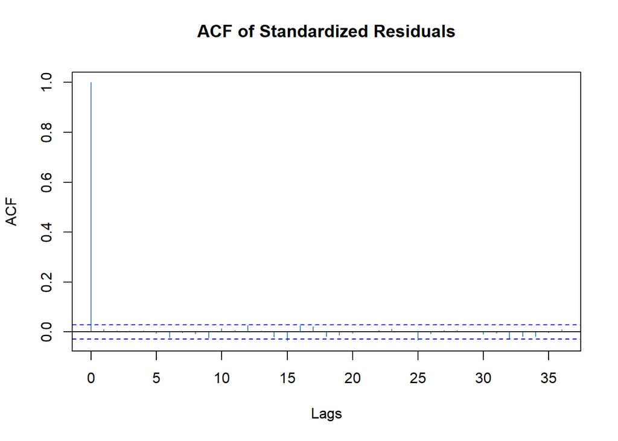

```r
plot(k.ar5garch21, which = 10)
```

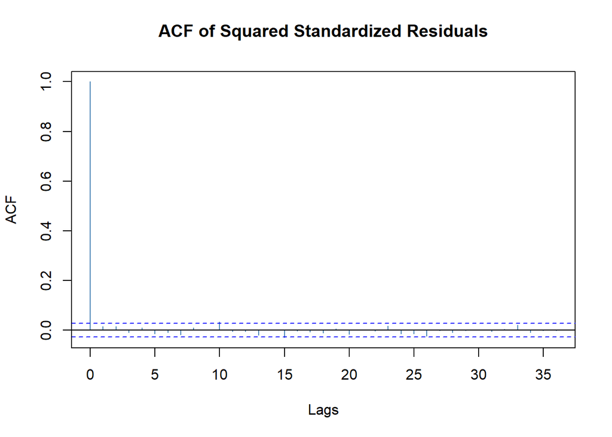

```r
plot(k.ar5garch21, which = 11)
```

Both ACF figures show no significant lags.

### AR(5)-GARCH(1,1)

Let’s reestimate GARCH(1,1) and ARCH(10) with AR(5) part:

```r
k.ar5garch11 <- garchFit(~arma(5, 0) + garch(1, 1),
                         data = SP500$r,
                         include.mean = TRUE,
                         cond.dist = "norm",
                         trace = FALSE)
summary(k.ar5garch11)
```

```
##
## Title:
##  GARCH Modelling
##
## Call:
##  garchFit(formula = ~arma(5, 0) + garch(1, 1), data = SP500$r,
##     cond.dist = "norm", include.mean = TRUE, trace = FALSE)
##
## Mean and Variance Equation:
##  data ~ arma(5, 0) + garch(1, 1)
## <environment: 0x0000025353f04e70>
##  [data = SP500$r]
##
## Conditional Distribution:
##  norm
##
## Coefficient(s):
##            mu            ar1            ar2            ar3            ar4
##  0.0006492849  -0.0626807756  -0.0291813969  -0.0122284000  -0.0106669530
##           ar5          omega         alpha1          beta1
## -0.0375103026   0.0000019097   0.1090581092   0.8762102078
##
## Std. Errors:
##  based on Hessian
##
## Error Analysis:
##             Estimate    Std. Error  t value         Pr(>|t|)
## mu      0.0006492849  0.0001161821    5.589 0.00000002290277 ***
## ar1    -0.0626807756  0.0154819078   -4.049 0.00005151463256 ***
## ar2    -0.0291813969  0.0153023866   -1.907           0.0565 .
## ar3    -0.0122284000  0.0151773473   -0.806           0.4204
## ar4    -0.0106669530  0.0150775442   -0.707           0.4793
## ar5    -0.0375103026  0.0149595913   -2.507           0.0122 *
## omega   0.0000019097  0.0000002757    6.926 0.00000000000434 ***
## alpha1  0.1090581092  0.0093229385   11.698          < 2e-16 ***
## beta1   0.8762102078  0.0097383079   89.976          < 2e-16 ***
## ---
## Signif. codes:  0 '***' 0.001 '**' 0.01 '*' 0.05 '.' 0.1 ' ' 1
##
## Log Likelihood:
##  15788.76    normalized:  3.245378
##
## Description:
##  Wed May 10 15:25:58 2023 by user: macie
##
##
## Standardised Residuals Tests:
##                                 Statistic p-Value
##  Jarque-Bera Test   R    Chi^2  822.9079  0
##  Shapiro-Wilk Test  R    W      0.9810288 0
##  Ljung-Box Test     R    Q(10)  7.563451  0.6713937
##  Ljung-Box Test     R    Q(15)  18.35947  0.244239
##  Ljung-Box Test     R    Q(20)  26.06744  0.1635961
##  Ljung-Box Test     R^2  Q(10)  16.41112  0.08845288
##  Ljung-Box Test     R^2  Q(15)  23.12779  0.08146411
##  Ljung-Box Test     R^2  Q(20)  25.39395  0.1867729
##  LM Arch Test       R    TR^2   16.13026  0.1853425
##
## Information Criterion Statistics:
##       AIC       BIC       SIC      HQIC
## -6.487056 -6.475050 -6.487063 -6.482842
```

### AR(5)-ARCH(10)

```r
k.ar5arch10 <- garchFit(~arma(5, 0) + garch(10, 0),
                         data = SP500$r,
                         include.mean = TRUE,
                         cond.dist = "norm",
                         trace = FALSE)
summary(k.ar5arch10)
```

```
##
## Title:
##  GARCH Modelling
##
## Call:
##  garchFit(formula = ~arma(5, 0) + garch(10, 0), data = SP500$r,
##     cond.dist = "norm", include.mean = TRUE, trace = FALSE)
##
## Mean and Variance Equation:
##  data ~ arma(5, 0) + garch(10, 0)
## <environment: 0x00000253511d0710>
##  [data = SP500$r]
##
## Conditional Distribution:
##  norm
##
## Coefficient(s):
##           mu           ar1           ar2           ar3           ar4
##  0.000287879  -0.056993486  -0.024262252  -0.006315369  -0.001135829
##          ar5         omega        alpha1        alpha2        alpha3
## -0.031358596   0.000018909   0.064209617   0.135818902   0.105873755
##       alpha4        alpha5        alpha6        alpha7        alpha8
##  0.113213419   0.079019843   0.070548868   0.062401613   0.102835038
##       alpha9       alpha10
##  0.073353220   0.065640110
##
## Std. Errors:
##  based on Hessian
##
## Error Analysis:
##             Estimate   Std. Error  t value          Pr(>|t|)
## mu       0.000287879  0.000114513    2.514            0.0119 *
## ar1     -0.056993486  0.014649348   -3.891            0.0001 ***
## ar2     -0.024262252  0.015467792   -1.569            0.1167
## ar3     -0.006315369  0.015011878   -0.421            0.6740
## ar4     -0.001135829  0.015262090   -0.074            0.9407
## ar5     -0.031358596  0.014866946   -2.109            0.0349 *
## omega    0.000018909  0.000001508   12.536           < 2e-16 ***
## alpha1   0.064209617  0.013816219    4.647 0.000003361309324 ***
## alpha2   0.135818902  0.018476653    7.351 0.000000000000197 ***
```

[output cut: 18 more lines]

```
## Standardised Residuals Tests:
##                                 Statistic p-Value
##  Jarque-Bera Test   R    Chi^2  714.1932  0
##  Shapiro-Wilk Test  R    W      0.9815896 0
##  Ljung-Box Test     R    Q(10)  5.468853  0.8577425
##  Ljung-Box Test     R    Q(15)  18.09638  0.2576324
##  Ljung-Box Test     R    Q(20)  26.2679   0.1571452
##  Ljung-Box Test     R^2  Q(10)  8.695432  0.5612314
##  Ljung-Box Test     R^2  Q(15)  11.7541   0.6975387
##  Ljung-Box Test     R^2  Q(20)  14.24161  0.8180376
##  LM Arch Test       R    TR^2   8.772229  0.7222522
##
## Information Criterion Statistics:
##       AIC       BIC       SIC      HQIC
## -6.481162 -6.458484 -6.481186 -6.473202
```

## Comparison

Which model has most favourable information criteria AIC and SBC?

To answer this question we will use the external function `compare_ICs_GARCH()` which is located in the `functions/compare_ICs_GARCH.R` file. It requires a list of names of existing (G)ARCH model results as an argument.

```r
compare_ICs_GARCH(c("k.arch1", "k.arch1a", "k.arch5", "k.arch10",
                    "k.garch11", "k.garch21", "k.ar5garch21",
                    "k.ar5garch11", "k.ar5arch10"))
```

```
## $ICs
##         AIC       BIC       SIC      HQIC        model
## 1 -6.118407 -6.114405 -6.118408 -6.117003      k.arch1
## 2 -6.117666 -6.114998 -6.117666 -6.116729     k.arch1a
## 3 -6.432811 -6.423473 -6.432815 -6.429533      k.arch5
## 4 -6.476821 -6.460813 -6.476833 -6.471203     k.arch10
## 5 -6.480545 -6.475209 -6.480547 -6.478673    k.garch11
## 6 -6.482037 -6.475368 -6.482040 -6.479697    k.garch21
## 7 -6.488726 -6.475386 -6.488734 -6.484044 k.ar5garch21
## 8 -6.487056 -6.475050 -6.487063 -6.482842 k.ar5garch11
## 9 -6.481162 -6.458484 -6.481186 -6.473202  k.ar5arch10
##
## $which.min
##  AIC  BIC  SIC HQIC
##    7    7    7    7
```

Most criteria give the same result: up to some point all consequtive models are better than the previous ones and finally AR(5)-GARCH(2,1) is the most attractive (according to all criteria).

## Diagnostics

Now, let’s assume that the final model is AR(5)-GARCH(2,1).

The questions we can ask are the following:

- Do standardized residuals follow normal distribution?
- Are standardized residuals a realization of the white noise process?
- Are **squared standardized residuals** a realization of the white noise process?

Lets remind the summary of the model and JB test result:

```r
summary(k.ar5garch21)
```

```
##
## Title:
##  GARCH Modelling
##
## Call:
##  garchFit(formula = ~arma(5, 0) + garch(2, 1), data = SP500$r,
##     cond.dist = "norm", include.mean = TRUE, trace = FALSE)
##
## Mean and Variance Equation:
##  data ~ arma(5, 0) + garch(2, 1)
## <environment: 0x0000025353ad2a70>
##  [data = SP500$r]
##
## Conditional Distribution:
##  norm
##
## Coefficient(s):
##            mu            ar1            ar2            ar3            ar4
##  0.0006510745  -0.0619571972  -0.0310592741  -0.0110380532  -0.0103344248
##           ar5          omega         alpha1         alpha2          beta1
## -0.0378877176   0.0000024104   0.0697032348   0.0596562962   0.8521811082
##
## Std. Errors:
##  based on Hessian
##
## Error Analysis:
##             Estimate    Std. Error  t value        Pr(>|t|)
## mu      0.0006510745  0.0001156991    5.627 0.0000000183046 ***
## ar1    -0.0619571972  0.0149170521   -4.153 0.0000327502940 ***
## ar2    -0.0310592741  0.0155031466   -2.003         0.04513 *
## ar3    -0.0110380532  0.0152538456   -0.724         0.46930
## ar4    -0.0103344248  0.0151272876   -0.683         0.49450
## ar5    -0.0378877176  0.0149860308   -2.528         0.01146 *
## omega   0.0000024104  0.0000003691    6.530 0.0000000000656 ***
## alpha1  0.0697032348  0.0137874076    5.056 0.0000004291022 ***
## alpha2  0.0596562962  0.0181845049    3.281         0.00104 **
## beta1   0.8521811082  0.0135677522   62.809         < 2e-16 ***
## ---
## Signif. codes:  0 '***' 0.001 '**' 0.01 '*' 0.05 '.' 0.1 ' ' 1
##
## Log Likelihood:
##  15793.83    normalized:  3.246418
##
## Description:
##  Wed May 10 15:25:51 2023 by user: macie
##
##
## Standardised Residuals Tests:
##                                 Statistic p-Value
##  Jarque-Bera Test   R    Chi^2  852.0334  0
##  Shapiro-Wilk Test  R    W      0.9805123 0
##  Ljung-Box Test     R    Q(10)  7.084543  0.7174402
##  Ljung-Box Test     R    Q(15)  18.22773  0.2508824
##  Ljung-Box Test     R    Q(20)  25.95364  0.1673485
##  Ljung-Box Test     R^2  Q(10)  11.84522  0.295549
##  Ljung-Box Test     R^2  Q(15)  18.47928  0.238307
##  Ljung-Box Test     R^2  Q(20)  20.71818  0.413884
##  LM Arch Test       R    TR^2   11.87074  0.4561158
##
## Information Criterion Statistics:
##       AIC       BIC       SIC      HQIC
## -6.488726 -6.475386 -6.488734 -6.484044
```

Lets also apply the JB test “manually”. Standardized residuals are residuals divided by conditional stdev. Hence, we have to extract from the object with the model two elements: 1) residuals, 2) estimates of the conditional variance function.

Let’s see the structure of the object:

```r
str(k.ar5garch21)
```

```
## Formal class 'fGARCH' [package "fGarch"] with 11 slots
##   ..@ call       : language garchFit(formula = ~arma(5, 0) + garch(2, 1), data = SP500$r, cond.dist = "norm",      include.mean = TRUE, trace = FALSE)
##   ..@ formula    :Class 'formula'  language data ~ arma(5, 0) + garch(2, 1)
##   .. .. ..- attr(*, ".Environment")=<environment: 0x0000025353ad2a70>
##   .. .. ..- attr(*, "data")= chr "data = SP500$r"
##   ..@ method     : chr "Max Log-Likelihood Estimation"
##   ..@ data       : Named num [1:4865] -0.009595 -0.039099 0.00192 0.000955 0.02673 ...
##   .. ..- attr(*, "names")= chr [1:4865] "2000-01-03" "2000-01-04" "2000-01-05" "2000-01-06" ...
##   ..@ fit        :List of 17
##   .. ..$ par        : Named num [1:10] 0.000651 -0.061957 -0.031059 -0.011038 -0.010334 ...
##   .. .. ..- attr(*, "names")= chr [1:10] "mu" "ar1" "ar2" "ar3" ...
##   .. ..$ objective  : num 5720
##   .. ..$ convergence: int 1
##   .. ..$ iterations : int 570
##   .. ..$ evaluations: Named int [1:2] 606 8455
##   .. .. ..- attr(*, "names")= chr [1:2] "function" "gradient"
##   .. ..$ message    : chr "singular convergence (7)"
##   .. ..$ value      : Named num -15794
##   .. .. ..- attr(*, "names")= chr "LogLikelihood"
##   .. ..$ coef       : Named num [1:10] 0.000651 -0.061957 -0.031059 -0.011038 -0.010334 ...
##   .. .. ..- attr(*, "names")= chr [1:10] "mu" "ar1" "ar2" "ar3" ...
##   .. ..$ llh        : Named num -15794
##   .. .. ..- attr(*, "names")= chr "LogLikelihood"
##   .. ..$ hessian    : num [1:10, 1:10] -78433972 -40882 -41214 -54843 -59002 ...
##   .. .. ..- attr(*, "dimnames")=List of 2
##   .. .. .. ..$ : chr [1:10] "mu" "ar1" "ar2" "ar3" ...
##   .. .. .. ..$ : chr [1:10] "mu" "ar1" "ar2" "ar3" ...
##   .. .. ..- attr(*, "time")= 'difftime' num 0.258971929550171
##   .. .. .. ..- attr(*, "units")= chr "secs"
##   .. ..$ ics        : Named num [1:4] -6.49 -6.48 -6.49 -6.48
##   .. .. ..- attr(*, "names")= chr [1:4] "AIC" "BIC" "SIC" "HQIC"
##   .. ..$ series     :List of 10
##   .. .. ..$ model    : chr [1:2] "arma" "garch"
##   .. .. ..$ order    : Named num [1:4] 5 0 2 1
##   .. .. .. ..- attr(*, "names")= chr [1:4] "u" "v" "p" "q"
##   .. .. ..$ max.order: num 5
##   .. .. ..$ z        : num [1:4865] 0 0 0 0 0 ...
##   .. .. ..$ h        : num [1:4865] 0.0001423 0.0001423 0.0001237 0.0001078 0.0000943 ...
##   .. .. ..$ x        : Named num [1:4865] -0.009595 -0.039099 0.00192 0.000955 0.02673 ...
##   .. .. .. ..- attr(*, "names")= chr [1:4865] "2000-01-03" "2000-01-04" "2000-01-05" "2000-01-06" ...
```

[output cut: 49 more lines]

```
##   .. ..$ se.coef    : Named num [1:10] 0.000116 0.014917 0.015503 0.015254 0.015127 ...
##   .. .. ..- attr(*, "names")= chr [1:10] "mu" "ar1" "ar2" "ar3" ...
##   .. ..$ tval       : Named num [1:10] 5.627 -4.153 -2.003 -0.724 -0.683 ...
##   .. .. ..- attr(*, "names")= chr [1:10] "mu" "ar1" "ar2" "ar3" ...
##   .. ..$ matcoef    : num [1:10, 1:4] 0.000651 -0.061957 -0.031059 -0.011038 -0.010334 ...
##   .. .. ..- attr(*, "dimnames")=List of 2
##   .. .. .. ..$ : chr [1:10] "mu" "ar1" "ar2" "ar3" ...
##   .. .. .. ..$ : chr [1:4] " Estimate" " Std. Error" " t value" "Pr(>|t|)"
##   ..@ residuals  : num [1:4865] 0 0 0 0 0 ...
##   ..@ fitted     : Named num [1:4865] -0.009595 -0.039099 0.00192 0.000955 0.02673 ...
##   .. ..- attr(*, "names")= chr [1:4865] "2000-01-03" "2000-01-04" "2000-01-05" "2000-01-06" ...
##   ..@ h.t        : num [1:4865] 0.0001423 0.0001423 0.0001237 0.0001078 0.0000943 ...
##   ..@ sigma.t    : num [1:4865] 0.01193 0.01193 0.01112 0.01038 0.00971 ...
##   ..@ title      : chr "GARCH Modelling"
##   ..@ description: chr "Wed May 10 15:25:51 2023 by user: macie"
```

Hence, the appropriate elements are: `@residuals` and `@h.t`.

Finally, we hace calculate standardized residuals:

```r
stdres <- k.ar5garch21@residuals/sqrt(k.ar5garch21@h.t)
```

and apply the Jarque-Bera test:

```r
jarque.bera.test(stdres)
```

```
##
##  Jarque Bera Test
##
## data:  stdres
## X-squared = 852.03, df = 2, p-value < 2.2e-16
```

The result is exactly the same as above. Normality of standardized residuals is strongly rejected. This is confirmed by the histogram as well:

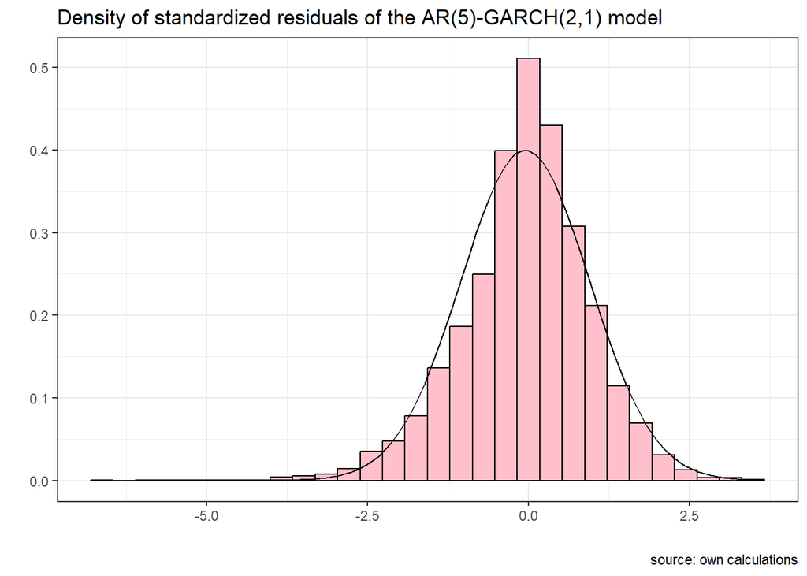

```r
tibble(stdres = stdres) %>%
  ggplot(aes(stdres)) +
  geom_histogram(aes(y =..density..),
                 colour = "black",
                 fill = "pink") +
  stat_function(fun = dnorm,
                args = list(mean = mean(stdres),
                            sd = sd(stdres))) +
  theme_bw() +
  labs(
    title = "Density of standardized residuals of the AR(5)-GARCH(2,1) model",
    y = "", x = "",
    caption = "source: own calculations"
  )
```

# Exercises 11

Perform similar analysis for any other time series downloaded from Yahoo! Finance service.

## Exercise 11.1

Get the data for a selected asset. Compute log-returns. Present the data on the plot

## Exercise 11.2

Check normality of returns using a formal test. Test for autocorrelation of returns and squared returns of the analyzed asset.

## Exercise 11.3

Find the best GARCH(q,p) model (possibly with AR or/and MA component added). What criteria did you use for model selection? Does the model pass all the diagnostic checks?

## Exercise 11.4

For a finally selected model check if its standardized residuals follow a normal distribution and are not autocorrelated.